# Week 3 Shooting

SL

2024-03-07

# Upload data and show summary

```r
library(tidyverse)
shooting_df = read_csv('https://data.cityofnewyork.us/api/views/833y-fsy8/rows.csv?accessType=DOWNLOAD')
summary(shooting_df)
```

```
##   INCIDENT_KEY        OCCUR_DATE         OCCUR_TIME           BORO
##  Min.   :  9953245   Length:27312       Length:27312      Length:27312
##  1st Qu.: 63860880   Class :character   Class1:hms        Class :character
##  Median : 90372218   Mode  :character   Class2:difftime   Mode  :character
##  Mean   :120860536                      Mode  :numeric
##  3rd Qu.:188810230
##  Max.   :261190187
##
##  LOC_OF_OCCUR_DESC     PRECINCT      JURISDICTION_CODE LOC_CLASSFCTN_DESC
##  Length:27312       Min.   :  1.00   Min.   :0.0000    Length:27312
##  Class :character   1st Qu.: 44.00   1st Qu.:0.0000    Class :character
##  Mode  :character   Median : 68.00   Median :0.0000    Mode  :character
##                     Mean   : 65.64   Mean   :0.3269
##                     3rd Qu.: 81.00   3rd Qu.:0.0000
##                     Max.   :123.00   Max.   :2.0000
##                                      NA's   :2
##  LOCATION_DESC      STATISTICAL_MURDER_FLAG PERP_AGE_GROUP
##  Length:27312       Mode :logical           Length:27312
##  Class :character   FALSE:22046             Class :character
##  Mode  :character   TRUE :5266              Mode  :character
##
##
##
##
##    PERP_SEX          PERP_RACE         VIC_AGE_GROUP        VIC_SEX
##  Length:27312       Length:27312       Length:27312       Length:27312
##  Class :character   Class :character   Class :character   Class :character
##  Mode  :character   Mode  :character   Mode  :character   Mode  :character
##
##
##
##
##    VIC_RACE           X_COORD_CD        Y_COORD_CD        Latitude
##  Length:27312       Min.   : 914928   Min.   :125757   Min.   :40.51
##  Class :character   1st Qu.:1000029   1st Qu.:182834   1st Qu.:40.67
##  Mode  :character   Median :1007731   Median :194487   Median :40.70
##                     Mean   :1009449   Mean   :208127   Mean   :40.74
##                     3rd Qu.:1016838   3rd Qu.:239518   3rd Qu.:40.82
##                     Max.   :1066815   Max.   :271128   Max.   :40.91
##                                                        NA's   :10
##    Longitude        Lon_Lat
##  Min.   :-74.25   Length:27312
##  1st Qu.:-73.94   Class :character
##  Median :-73.92   Mode  :character
##  Mean   :-73.91
##  3rd Qu.:-73.88
##  Max.   :-73.70
##  NA's   :10
```

# Cleaning

```r
cols = c('BORO', 'LOC_OF_OCCUR_DESC', 'PRECINCT', 'JURISDICTION_CODE','LOC_CLASSFCTN_DESC', 'LOCATION_DESC','STATISTICAL_MURDER_FLAG',
         'PERP_AGE_GROUP', 'PERP_SEX', 'PERP_RACE', 'VIC_AGE_GROUP', 'VIC_SEX',  'VIC_RACE')
shooting_df= shooting_df %>%
  mutate(OCCUR_DATE = mdy(OCCUR_DATE)) %>%
  mutate_at(cols, factor) #%>%
  #select(-c(Lat, Long_))

summary(shooting_df)
```

```
##   INCIDENT_KEY         OCCUR_DATE          OCCUR_TIME
##  Min.   :  9953245   Min.   :2006-01-01   Length:27312
##  1st Qu.: 63860880   1st Qu.:2009-07-18   Class1:hms
##  Median : 90372218   Median :2013-04-29   Class2:difftime
##  Mean   :120860536   Mean   :2014-01-06   Mode  :numeric
##  3rd Qu.:188810230   3rd Qu.:2018-10-15
##  Max.   :261190187   Max.   :2022-12-31
##
##             BORO       LOC_OF_OCCUR_DESC    PRECINCT     JURISDICTION_CODE
##  BRONX        : 7937   INSIDE :  242     75     : 1557   0   :22809
##  BROOKLYN     :10933   OUTSIDE: 1474     73     : 1452   1   :   74
##  MANHATTAN    : 3572   NA's   :25596     67     : 1216   2   : 4427
##  QUEENS       : 4094                     44     : 1020   NA's:    2
##  STATEN ISLAND:  776                     79     : 1012
##                                          47     :  953
##                                          (Other):20102
##   LOC_CLASSFCTN_DESC                   LOCATION_DESC   STATISTICAL_MURDER_FLAG
##  STREET    : 1103    MULTI DWELL - PUBLIC HOUS: 4832   FALSE:22046
##  HOUSING   :  280    MULTI DWELL - APT BUILD  : 2835   TRUE : 5266
##  DWELLING  :  127    (null)                   :  977
##  COMMERCIAL:  100    PVT HOUSE                :  951
##  OTHER     :   31    GROCERY/BODEGA           :  694
##  (Other)   :   75    (Other)                  : 2046
##  NA's      :25596    NA's                     :14977
##  PERP_AGE_GROUP   PERP_SEX              PERP_RACE     VIC_AGE_GROUP   VIC_SEX
##  18-24  :6222   (null):  640   BLACK         :11432   <18    : 2839   F: 2615
##  25-44  :5687   F     :  424   WHITE HISPANIC: 2341   1022   :    1   M:24686
##  UNKNOWN:3148   M     :15439   UNKNOWN       : 1836   18-24  :10086   U:   11
##  <18    :1591   U     : 1499   BLACK HISPANIC: 1314   25-44  :12281
##  (null) : 640   NA's  : 9310   (null)        :  640   45-64  : 1863
##  (Other): 680                  (Other)       :  439   65+    :  181
##  NA's   :9344                  NA's          : 9310   UNKNOWN:   61
##                            VIC_RACE       X_COORD_CD        Y_COORD_CD
##  AMERICAN INDIAN/ALASKAN NATIVE:   10   Min.   : 914928   Min.   :125757
##  ASIAN / PACIFIC ISLANDER      :  404   1st Qu.:1000029   1st Qu.:182834
##  BLACK                         :19439   Median :1007731   Median :194487
##  BLACK HISPANIC                : 2646   Mean   :1009449   Mean   :208127
##  UNKNOWN                       :   66   3rd Qu.:1016838   3rd Qu.:239518
##  WHITE                         :  698   Max.   :1066815   Max.   :271128
##  WHITE HISPANIC                : 4049
##     Latitude       Longitude        Lon_Lat
##  Min.   :40.51   Min.   :-74.25   Length:27312
##  1st Qu.:40.67   1st Qu.:-73.94   Class :character
##  Median :40.70   Median :-73.92   Mode  :character
##  Mean   :40.74   Mean   :-73.91
##  3rd Qu.:40.82   3rd Qu.:-73.88
##  Max.   :40.91   Max.   :-73.70
##  NA's   :10      NA's   :10
```

A few columns have missing data. Given the data columns, this data may be missing because certain details were not collected. In other words, relabeling the NA to ‘unknown’ may be more appropriate. A few of the other columns already use this ‘unknown’ label for uncollected data.

# Mutating

```r
shooting_df$year = format(as.Date(shooting_df$OCCUR_DATE, format="%Y/%m/%d"),"%Y")
```

# Including Plots

## Cases over time

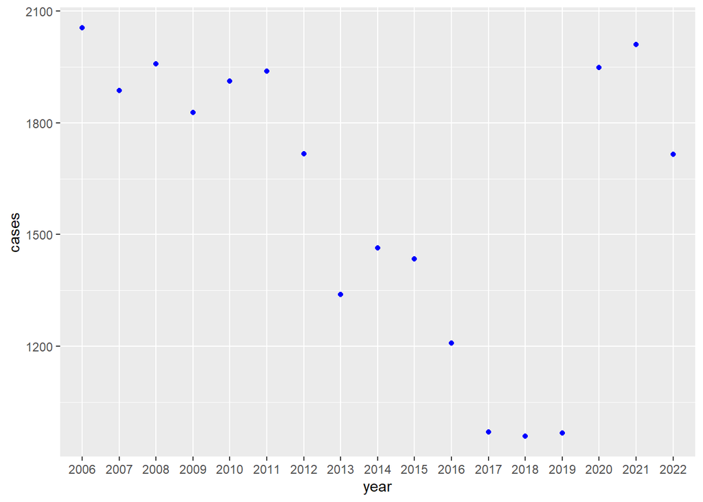

```r
shooting_tot = shooting_df %>%
  group_by(year) %>%
  summarize(cases = n()) %>%
  select(year, cases) %>%
  ungroup()

shooting_tot %>% ggplot() +
  geom_point(aes(x = year, y = cases), color = 'blue')
```

Question based on this plot: What happened in 2017 - 2019 to prompt this sudden decrease in crime rates?

## Case by location

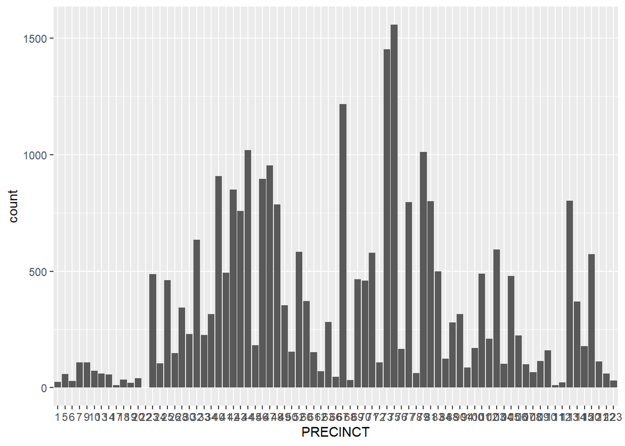

```r
shooting_pre_tot = shooting_df %>%
  group_by(PRECINCT) %>%
  summarize(cases = n()) %>%
  select(PRECINCT, cases) %>%
  ungroup()

shooting_df %>% ggplot() +
  geom_bar(aes(PRECINCT))
```

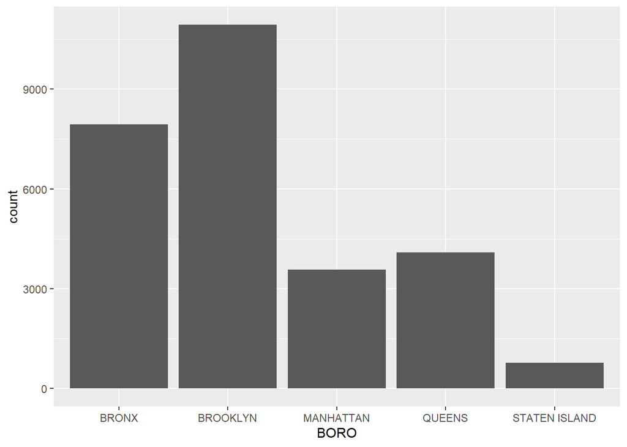

```r
shooting_df %>% ggplot() +
  geom_bar(aes(BORO))
```

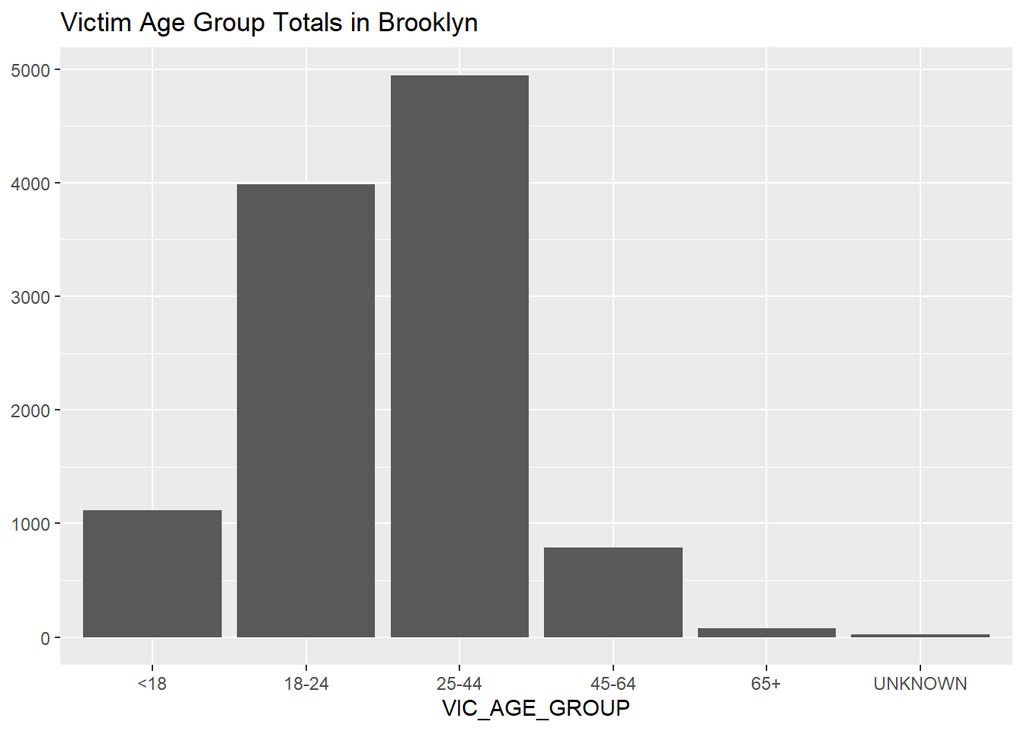

```r
b = 'Brooklyn'
shooting_df %>%
  filter(BORO == 'BROOKLYN') %>%
  ggplot() +
  geom_bar(aes(VIC_AGE_GROUP)) +
  labs(title = str_c('Victim Age Group Totals in ', b), y = NULL)
```

Questions based on these plots:

- Do certain Boros have more precincts? Are the number of precincts based on size of covered area or number of crimes?
- Could income/wealth be playing a role in crime rates, where Boros that are less well off are more likely to have high crime rates?
- What is the age population of Brooklyn? Could there just be more younger individuals in Brooklyn, thus they are more likely to be victims of crimes? Versus perpetrators specifically focusing on younger people?

# Model - Do Murder cases decrease by year?

```
## `geom_line()`: Each group consists of only one observation.
## i Do you need to adjust the group aesthetic?
```

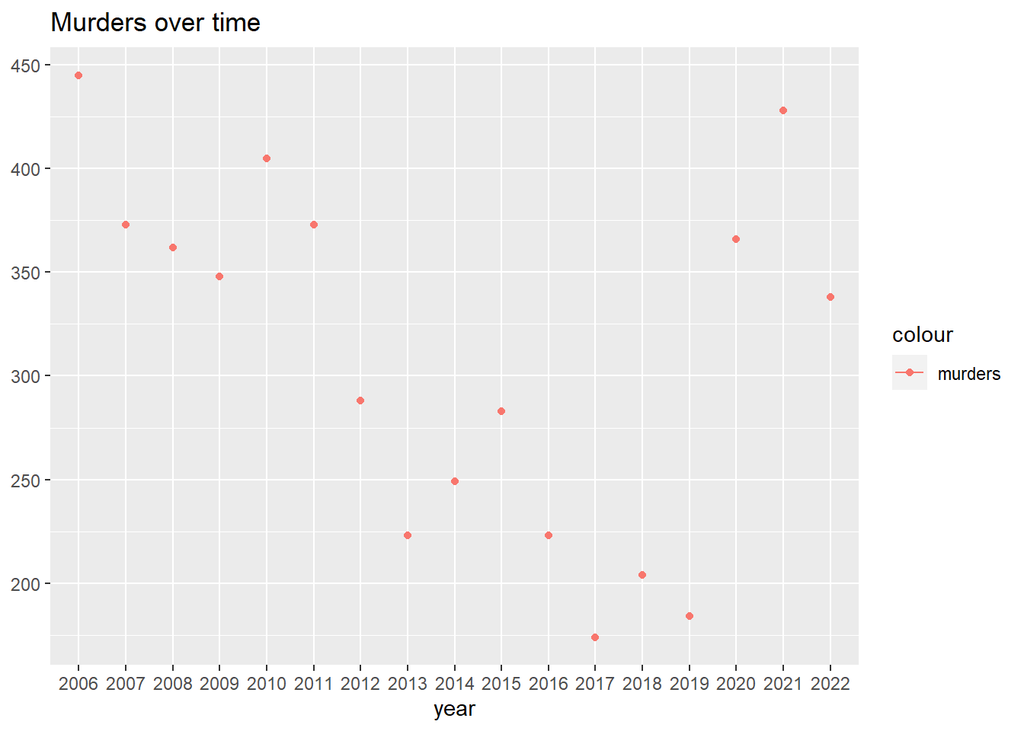

```r
shooting_mur_tot = shooting_df %>%
  filter(STATISTICAL_MURDER_FLAG == 'TRUE')%>%
  group_by(year) %>%
  summarize(murders = n()) %>%
  select(year, murders) %>%
  ungroup()


shooting_mur_tot %>%
  ggplot(aes(x = year, y = murders)) +
  geom_line(aes(color = 'murders')) +
  geom_point(aes(color = 'murders')) +
  labs(title = str_c('Murders over time '), y = NULL)
```

```r
shooting_mur_tot$year<-as.numeric(shooting_mur_tot$year)

mod = lm(murders ~ year, data = shooting_mur_tot)
summary(mod)
```

```
##
## Call:
## lm(formula = murders ~ year, data = shooting_mur_tot)
##
## Residuals:
##      Min       1Q   Median       3Q      Max
## -115.632  -73.343    4.681   68.392  165.211
##
## Coefficients:
##              Estimate Std. Error t value Pr(>|t|)
## (Intercept) 13825.284   8321.696   1.661    0.117
## year           -6.711      4.132  -1.624    0.125
##
## Residual standard error: 83.46 on 15 degrees of freedom
## Multiple R-squared:  0.1496, Adjusted R-squared:  0.09286
## F-statistic: 2.638 on 1 and 15 DF,  p-value: 0.1252
```

# Conclusion

The drastic drop in crimes and murders in the years 2017-2019 may suggest some bias in data collection during those times. Personally, I would want to investigate how crimes and murders were recorded during that time period and if any changes in procedures were made.

In terms of personal biases, as a young female, I could be more sympathetic towards victims in my age range, which is the 25-44 age range.